# Turisti_kolokvij

```python
import pandas as pd
```

```python
turisti=pd.read_excel("Turisti.xlsx")
```

```python
turisti.head()
```

|  | Country | City | NoDays | Motivation | Price | NrPeople | NrCh | Service | Transport | Loyalty | Paymenttype |
| --- | --- | --- | --- | --- | --- | --- | --- | --- | --- | --- | --- |
| 0 | Italija | Padova | 10.0 | tourism | 1700.0 | 4.0 | 2.0 | 700.0 | bus | 6.0 | 2.0 |
| 1 | Portugal | Lisbon | 11.0 | tourism | 2475.0 | 6.0 | 4.0 | 250.0 | train | 3.0 | 2.0 |
| 2 | Italija | Milano | 5.0 | tourism | 850.0 | 5.0 | 4.0 | 250.0 | airplane | 4.0 | 1.0 |
| 3 | Španjolska | Barcelona | 7.0 | tourism | 1505.0 | 5.0 | 3.0 | 500.0 | bus | 4.0 | 1.0 |
| 4 | Njemačka | Berlin | 12.0 | tourism | 2280.0 | 4.0 | 2.0 | 700.0 | train | 5.0 | 2.0 |

```python
turisti.describe()
```

|  | NoDays | Price | NrPeople | NrCh | Service | Loyalty | Paymenttype |
| --- | --- | --- | --- | --- | --- | --- | --- |
| count | 299.000000 | 299.000000 | 298.000000 | 298.000000 | 299.000000 | 299.000000 | 299.000000 |
| mean | 8.187291 | 2228.377926 | 3.174497 | 2.194631 | 794.481605 | 3.608696 | 1.936455 |
| std | 2.261074 | 9749.828055 | 1.498513 | 12.831557 | 224.680195 | 1.746730 | 0.785337 |
| min | 5.000000 | 85.000000 | 1.000000 | 0.000000 | 250.000000 | 1.000000 | 1.000000 |
| 25% | 7.000000 | 1190.000000 | 2.000000 | 0.000000 | 700.000000 | 2.000000 | 1.000000 |
| 50% | 9.000000 | 1700.000000 | 4.000000 | 2.000000 | 700.000000 | 4.000000 | 2.000000 |
| 75% | 10.000000 | 2070.000000 | 4.000000 | 2.000000 | 1000.000000 | 5.000000 | 3.000000 |
| max | 12.000000 | 170000.000000 | 6.000000 | 222.000000 | 1000.000000 | 6.000000 | 3.000000 |

```python
turisti.info()
```

```
<class 'pandas.core.frame.DataFrame'>
RangeIndex: 300 entries, 0 to 299
Data columns (total 11 columns):
 #   Column       Non-Null Count  Dtype
---  ------       --------------  -----
 0   Country      299 non-null    object
 1   City         298 non-null    object
 2   NoDays       299 non-null    float64
 3   Motivation   297 non-null    object
 4   Price        299 non-null    float64
 5   NrPeople     298 non-null    float64
 6   NrCh         298 non-null    float64
 7   Service      299 non-null    float64
 8   Transport    298 non-null    object
 9   Loyalty      299 non-null    float64
 10  Paymenttype  299 non-null    float64
dtypes: float64(7), object(4)
memory usage: 25.9+ KB
```

```python
import matplotlib.pyplot as plt
%matplotlib inline
```

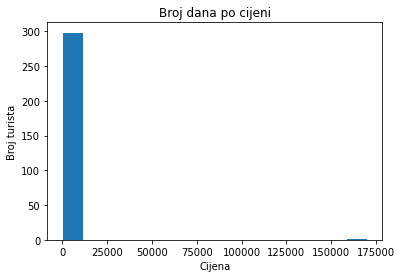

```python
plt.hist (turisti.Price, bins = 15)
plt.xlabel("Cijena")
plt.ylabel ("Broj turista")
plt.title ("Broj dana po cijeni")
```

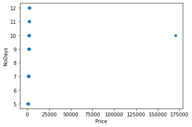

```python
turisti.plot(kind="scatter", x="Price", y="NoDays")
```

```python
turisti.loc [turisti["Price"] >=150000, ["Country","City","NrPeople","Price","Service"]]
```

|  | Country | City | NrPeople | Price | Service |
| --- | --- | --- | --- | --- | --- |
| 82 | Italija | Padova | 5.0 | 170000.0 | 500.0 |

```python
cijena_mean=turisti["Price"].mean()
```

```python
cijena_mean
```

```
2228.3779264214045
```

```python
cijena_std=turisti["Price"].std()
```

```python
cijena_std
```

```
9749.828055323353
```

```python
turisti["zscore_cijena"]=(turisti["Price"]-cijena_mean)/cijena_std
```

```python
turisti
```

|  | Country | City | NoDays | Motivation | Price | NrPeople | NrCh | Service | Transport | Loyalty | Paymenttype | zscore_cijena |
| --- | --- | --- | --- | --- | --- | --- | --- | --- | --- | --- | --- | --- |
| 0 | Italija | Padova | 10.0 | tourism | 1700.0 | 4.0 | 2.0 | 700.0 | bus | 6.0 | 2.0 | -0.054194 |
| 1 | Portugal | Lisbon | 11.0 | tourism | 2475.0 | 6.0 | 4.0 | 250.0 | train | 3.0 | 2.0 | 0.025295 |
| 2 | Italija | Milano | 5.0 | tourism | 850.0 | 5.0 | 4.0 | 250.0 | airplane | 4.0 | 1.0 | -0.141375 |
| 3 | Španjolska | Barcelona | 7.0 | tourism | 1505.0 | 5.0 | 3.0 | 500.0 | bus | 4.0 | 1.0 | -0.074194 |
| 4 | Njemačka | Berlin | 12.0 | tourism | 2280.0 | 4.0 | 2.0 | 700.0 | train | 5.0 | 2.0 | 0.005295 |
| ... | ... | ... | ... | ... | ... | ... | ... | ... | ... | ... | ... | ... |
| 295 | Italija | Rome | 5.0 | business | 850.0 | 1.0 | 0.0 | 1000.0 | airplane | 2.0 | 2.0 | -0.141375 |
| 296 | Portugal | Lisbon | 11.0 | tourism | 2475.0 | 3.0 | 1.0 | 1000.0 | train | 4.0 | 2.0 | 0.025295 |
| 297 | Italija | Padova | 10.0 | tourism | 1700.0 | 3.0 | 1.0 | 1000.0 | bus | 2.0 | 1.0 | -0.054194 |
| 298 | Island | Reykjavík | 10.0 | tourism | 2500.0 | 4.0 | 2.0 | 700.0 | Airplane | 5.0 | 1.0 | 0.027859 |
| 299 | Island | Reykjavík | 10.0 | tourism | 2500.0 | 3.0 | 1.0 | 1000.0 | Airplane | 6.0 | 2.0 | 0.027859 |

300 rows × 12 columns

```python
turisti[turisti["zscore_cijena"]<3]
```

|  | Country | City | NoDays | Motivation | Price | NrPeople | NrCh | Service | Transport | Loyalty | Paymenttype | zscore_cijena |
| --- | --- | --- | --- | --- | --- | --- | --- | --- | --- | --- | --- | --- |
| 0 | Italija | Padova | 10.0 | tourism | 1700.0 | 4.0 | 2.0 | 700.0 | bus | 6.0 | 2.0 | -0.054194 |
| 1 | Portugal | Lisbon | 11.0 | tourism | 2475.0 | 6.0 | 4.0 | 250.0 | train | 3.0 | 2.0 | 0.025295 |
| 2 | Italija | Milano | 5.0 | tourism | 850.0 | 5.0 | 4.0 | 250.0 | airplane | 4.0 | 1.0 | -0.141375 |
| 3 | Španjolska | Barcelona | 7.0 | tourism | 1505.0 | 5.0 | 3.0 | 500.0 | bus | 4.0 | 1.0 | -0.074194 |
| 4 | Njemačka | Berlin | 12.0 | tourism | 2280.0 | 4.0 | 2.0 | 700.0 | train | 5.0 | 2.0 | 0.005295 |
| ... | ... | ... | ... | ... | ... | ... | ... | ... | ... | ... | ... | ... |
| 295 | Italija | Rome | 5.0 | business | 850.0 | 1.0 | 0.0 | 1000.0 | airplane | 2.0 | 2.0 | -0.141375 |
| 296 | Portugal | Lisbon | 11.0 | tourism | 2475.0 | 3.0 | 1.0 | 1000.0 | train | 4.0 | 2.0 | 0.025295 |
| 297 | Italija | Padova | 10.0 | tourism | 1700.0 | 3.0 | 1.0 | 1000.0 | bus | 2.0 | 1.0 | -0.054194 |
| 298 | Island | Reykjavík | 10.0 | tourism | 2500.0 | 4.0 | 2.0 | 700.0 | Airplane | 5.0 | 1.0 | 0.027859 |
| 299 | Island | Reykjavík | 10.0 | tourism | 2500.0 | 3.0 | 1.0 | 1000.0 | Airplane | 6.0 | 2.0 | 0.027859 |

298 rows × 12 columns

```python
turisti_copy2=turisti[turisti["zscore_cijena"]<3]
```

```python
turisti[turisti["zscore_cijena"]>-3]
```

|  | Country | City | NoDays | Motivation | Price | NrPeople | NrCh | Service | Transport | Loyalty | Paymenttype | zscore_cijena |
| --- | --- | --- | --- | --- | --- | --- | --- | --- | --- | --- | --- | --- |
| 0 | Italija | Padova | 10.0 | tourism | 1700.0 | 4.0 | 2.0 | 700.0 | bus | 6.0 | 2.0 | -0.054194 |
| 1 | Portugal | Lisbon | 11.0 | tourism | 2475.0 | 6.0 | 4.0 | 250.0 | train | 3.0 | 2.0 | 0.025295 |
| 2 | Italija | Milano | 5.0 | tourism | 850.0 | 5.0 | 4.0 | 250.0 | airplane | 4.0 | 1.0 | -0.141375 |
| 3 | Španjolska | Barcelona | 7.0 | tourism | 1505.0 | 5.0 | 3.0 | 500.0 | bus | 4.0 | 1.0 | -0.074194 |
| 4 | Njemačka | Berlin | 12.0 | tourism | 2280.0 | 4.0 | 2.0 | 700.0 | train | 5.0 | 2.0 | 0.005295 |
| ... | ... | ... | ... | ... | ... | ... | ... | ... | ... | ... | ... | ... |
| 295 | Italija | Rome | 5.0 | business | 850.0 | 1.0 | 0.0 | 1000.0 | airplane | 2.0 | 2.0 | -0.141375 |
| 296 | Portugal | Lisbon | 11.0 | tourism | 2475.0 | 3.0 | 1.0 | 1000.0 | train | 4.0 | 2.0 | 0.025295 |
| 297 | Italija | Padova | 10.0 | tourism | 1700.0 | 3.0 | 1.0 | 1000.0 | bus | 2.0 | 1.0 | -0.054194 |
| 298 | Island | Reykjavík | 10.0 | tourism | 2500.0 | 4.0 | 2.0 | 700.0 | Airplane | 5.0 | 1.0 | 0.027859 |
| 299 | Island | Reykjavík | 10.0 | tourism | 2500.0 | 3.0 | 1.0 | 1000.0 | Airplane | 6.0 | 2.0 | 0.027859 |

299 rows × 12 columns

```python
turisti.duplicated().sum()
```

```
15
```

## Prema ovome podatku možemo vidjeti da ima 15 duplikata

```python
turisti[turisti.duplicated(keep=False)]
```

|  | Country | City | NoDays | Motivation | Price | NrPeople | NrCh | Service | Transport | Loyalty | Paymenttype | zscore_cijena |
| --- | --- | --- | --- | --- | --- | --- | --- | --- | --- | --- | --- | --- |
| 21 | Španjolska | Barcelona | 5.0 | business | 1075.0 | 1.0 | 0.0 | 1000.0 | airplane | 6.0 | 1.0 | -0.118297 |
| 30 | Njemačka | Berlin | 9.0 | tourism | 1710.0 | 3.0 | 1.0 | 1000.0 | train | 3.0 | 1.0 | -0.053168 |
| 35 | Italija | Rome | 10.0 | tourism | 1700.0 | 4.0 | 2.0 | 700.0 | bus | 1.0 | 2.0 | -0.054194 |
| 38 | Španjolska | Madrid | 5.0 | business | 1075.0 | 1.0 | 0.0 | 1000.0 | airplane | 1.0 | 1.0 | -0.118297 |
| 50 | Italija | Rome | 10.0 | tourism | 1700.0 | 4.0 | 2.0 | 700.0 | bus | 1.0 | 2.0 | -0.054194 |
| 63 | Njemačka | Berlin | 12.0 | tourism | 2280.0 | 4.0 | 2.0 | 700.0 | train | 6.0 | 3.0 | 0.005295 |
| 75 | Njemačka | Frankfurt | 7.0 | business | 1330.0 | 1.0 | 0.0 | 1000.0 | train | 6.0 | 1.0 | -0.092143 |
| 90 | Francuska | Paris | 7.0 | business | 1435.0 | 1.0 | 0.0 | 1000.0 | bus | 2.0 | 1.0 | -0.081374 |
| 91 | Italija | Rome | 5.0 | business | 850.0 | 1.0 | 0.0 | 1000.0 | airplane | 4.0 | 3.0 | -0.141375 |
| 93 | Španjolska | Madrid | 5.0 | business | 1075.0 | 1.0 | 0.0 | 1000.0 | airplane | 1.0 | 1.0 | -0.118297 |
| 95 | Francuska | Paris | 12.0 | tourism | 2460.0 | 3.0 | 1.0 | 1000.0 | train | 4.0 | 2.0 | 0.023757 |
| 101 | Španjolska | Barcelona | 5.0 | business | 1075.0 | 1.0 | 0.0 | 1000.0 | airplane | 6.0 | 1.0 | -0.118297 |
| 110 | Njemačka | Berlin | 12.0 | tourism | 2280.0 | 4.0 | 2.0 | 700.0 | train | 6.0 | 3.0 | 0.005295 |
| 122 | Njemačka | Berlin | 9.0 | tourism | 1710.0 | 3.0 | 1.0 | 1000.0 | train | 3.0 | 1.0 | -0.053168 |
| 123 | Španjolska | Barcelona | 5.0 | business | 1075.0 | 1.0 | 0.0 | 1000.0 | airplane | 6.0 | 2.0 | -0.118297 |
| 148 | Italija | Padova | 7.0 | business | 1190.0 | 1.0 | 0.0 | 1000.0 | bus | 4.0 | 1.0 | -0.106502 |
| 161 | Italija | Rome | 5.0 | business | 850.0 | 1.0 | 0.0 | 1000.0 | airplane | 4.0 | 3.0 | -0.141375 |
| 163 | Francuska | Paris | 7.0 | business | 1435.0 | 1.0 | 0.0 | 1000.0 | bus | 2.0 | 1.0 | -0.081374 |
| 181 | Njemačka | Frankfurt | 7.0 | business | 1330.0 | 1.0 | 0.0 | 1000.0 | train | 6.0 | 1.0 | -0.092143 |
| 188 | Francuska | Paris | 9.0 | tourism | 1845.0 | 4.0 | 2.0 | 700.0 | bus | 3.0 | 1.0 | -0.039322 |
| 191 | Italija | Padova | 7.0 | business | 1190.0 | 1.0 | 0.0 | 1000.0 | bus | 4.0 | 1.0 | -0.106502 |
| 217 | Španjolska | Barcelona | 5.0 | business | 1075.0 | 1.0 | 0.0 | 1000.0 | airplane | 6.0 | 2.0 | -0.118297 |
| 222 | Francuska | Paris | 12.0 | tourism | 2460.0 | 3.0 | 1.0 | 1000.0 | train | 4.0 | 2.0 | 0.023757 |
| 224 | Španjolska | Barcelona | 10.0 | tourism | 2150.0 | 3.0 | 1.0 | 1000.0 | bus | 3.0 | 1.0 | -0.008039 |
| 249 | Španjolska | Barcelona | 10.0 | tourism | 2150.0 | 3.0 | 1.0 | 1000.0 | bus | 3.0 | 1.0 | -0.008039 |
| 258 | Španjolska | Madrid | 7.0 | tourism | 1505.0 | 4.0 | 2.0 | 700.0 | bus | 2.0 | 1.0 | -0.074194 |
| 267 | Španjolska | Madrid | 7.0 | tourism | 1505.0 | 4.0 | 2.0 | 700.0 | bus | 2.0 | 1.0 | -0.074194 |
| 268 | Francuska | Paris | 9.0 | tourism | 1845.0 | 4.0 | 2.0 | 700.0 | bus | 3.0 | 1.0 | -0.039322 |
| 293 | Italija | Rome | 10.0 | tourism | 1700.0 | 4.0 | 2.0 | 700.0 | bus | 1.0 | 2.0 | -0.054194 |

```python
turisti.drop_duplicates(inplace=True)
```

```python
turisti.duplicated().sum()
```

```
0
```

## Sa gornjim dijelom koda smo maknuli sve duplikate

```python
turisti.isna().sum()
```

```
Country          1
City             2
NoDays           1
Motivation       3
Price            1
NrPeople         2
NrCh             2
Service          1
Transport        2
Loyalty          1
Paymenttype      1
zscore_cijena    1
dtype: int64
```

```python
turisti.loc[turisti.isnull().any(axis=1)]
```

|  | Country | City | NoDays | Motivation | Price | NrPeople | NrCh | Service | Transport | Loyalty | Paymenttype | zscore_cijena |
| --- | --- | --- | --- | --- | --- | --- | --- | --- | --- | --- | --- | --- |
| 39 | NaN | Madrid | 5.0 | tourism | 1075.0 | 4.0 | 2.0 | 700.0 | airplane | 4.0 | 1.0 | -0.118297 |
| 49 | Italija | NaN | NaN | NaN | NaN | NaN | NaN | NaN | NaN | NaN | NaN | NaN |
| 83 | Španjolska | Madrid | 7.0 | NaN | 1505.0 | 4.0 | 2.0 | 700.0 | bus | 4.0 | 2.0 | -0.074194 |
| 238 | Island | Reykjavík | 10.0 | tourism | 2500.0 | 1.0 | 0.0 | 1000.0 | NaN | 6.0 | 2.0 | 0.027859 |
| 241 | Italija | Milano | 5.0 | business | 850.0 | 1.0 | NaN | 1000.0 | airplane | 2.0 | 2.0 | -0.141375 |
| 270 | Španjolska | NaN | 7.0 | NaN | 1505.0 | NaN | 2.0 | 700.0 | bus | 5.0 | 1.0 | -0.074194 |

```python
turisti ["Country"].fillna("Španjolska", inplace=True)
```

```python
turisti.loc[turisti.isnull().any(axis=1)]
```

|  | Country | City | NoDays | Motivation | Price | NrPeople | NrCh | Service | Transport | Loyalty | Paymenttype | zscore_cijena |
| --- | --- | --- | --- | --- | --- | --- | --- | --- | --- | --- | --- | --- |
| 49 | Italija | NaN | NaN | NaN | NaN | NaN | NaN | NaN | NaN | NaN | NaN | NaN |
| 83 | Španjolska | Madrid | 7.0 | NaN | 1505.0 | 4.0 | 2.0 | 700.0 | bus | 4.0 | 2.0 | -0.074194 |
| 238 | Island | Reykjavík | 10.0 | tourism | 2500.0 | 1.0 | 0.0 | 1000.0 | NaN | 6.0 | 2.0 | 0.027859 |
| 241 | Italija | Milano | 5.0 | business | 850.0 | 1.0 | NaN | 1000.0 | airplane | 2.0 | 2.0 | -0.141375 |
| 270 | Španjolska | NaN | 7.0 | NaN | 1505.0 | NaN | 2.0 | 700.0 | bus | 5.0 | 1.0 | -0.074194 |

```python
turisti_copy=turisti
```

```python
turisti_copy.dropna(how = "any", thresh=3, inplace = True)
```

```python
turisti_copy
```

|  | Country | City | NoDays | Motivation | Price | NrPeople | NrCh | Service | Transport | Loyalty | Paymenttype | zscore_cijena |
| --- | --- | --- | --- | --- | --- | --- | --- | --- | --- | --- | --- | --- |
| 0 | Italija | Padova | 10.0 | tourism | 1700.0 | 4.0 | 2.0 | 700.0 | bus | 6.0 | 2.0 | -0.054194 |
| 1 | Portugal | Lisbon | 11.0 | tourism | 2475.0 | 6.0 | 4.0 | 250.0 | train | 3.0 | 2.0 | 0.025295 |
| 2 | Italija | Milano | 5.0 | tourism | 850.0 | 5.0 | 4.0 | 250.0 | airplane | 4.0 | 1.0 | -0.141375 |
| 3 | Španjolska | Barcelona | 7.0 | tourism | 1505.0 | 5.0 | 3.0 | 500.0 | bus | 4.0 | 1.0 | -0.074194 |
| 4 | Njemačka | Berlin | 12.0 | tourism | 2280.0 | 4.0 | 2.0 | 700.0 | train | 5.0 | 2.0 | 0.005295 |
| ... | ... | ... | ... | ... | ... | ... | ... | ... | ... | ... | ... | ... |
| 295 | Italija | Rome | 5.0 | business | 850.0 | 1.0 | 0.0 | 1000.0 | airplane | 2.0 | 2.0 | -0.141375 |
| 296 | Portugal | Lisbon | 11.0 | tourism | 2475.0 | 3.0 | 1.0 | 1000.0 | train | 4.0 | 2.0 | 0.025295 |
| 297 | Italija | Padova | 10.0 | tourism | 1700.0 | 3.0 | 1.0 | 1000.0 | bus | 2.0 | 1.0 | -0.054194 |
| 298 | Island | Reykjavík | 10.0 | tourism | 2500.0 | 4.0 | 2.0 | 700.0 | Airplane | 5.0 | 1.0 | 0.027859 |
| 299 | Island | Reykjavík | 10.0 | tourism | 2500.0 | 3.0 | 1.0 | 1000.0 | Airplane | 6.0 | 2.0 | 0.027859 |

284 rows × 12 columns

```python
turisti_copy.loc[turisti.isnull().any(axis=1)]
```

|  | Country | City | NoDays | Motivation | Price | NrPeople | NrCh | Service | Transport | Loyalty | Paymenttype | zscore_cijena |
| --- | --- | --- | --- | --- | --- | --- | --- | --- | --- | --- | --- | --- |
| 83 | Španjolska | Madrid | 7.0 | NaN | 1505.0 | 4.0 | 2.0 | 700.0 | bus | 4.0 | 2.0 | -0.074194 |
| 238 | Island | Reykjavík | 10.0 | tourism | 2500.0 | 1.0 | 0.0 | 1000.0 | NaN | 6.0 | 2.0 | 0.027859 |
| 241 | Italija | Milano | 5.0 | business | 850.0 | 1.0 | NaN | 1000.0 | airplane | 2.0 | 2.0 | -0.141375 |
| 270 | Španjolska | NaN | 7.0 | NaN | 1505.0 | NaN | 2.0 | 700.0 | bus | 5.0 | 1.0 | -0.074194 |

## Proba za dropanje Italije

```python
turisti.dropna(how = "any", thresh=3, inplace = True)
```

```python
turisti.loc[turisti.isnull().any(axis=1)]
```

|  | Country | City | NoDays | Motivation | Price | NrPeople | NrCh | Service | Transport | Loyalty | Paymenttype | zscore_cijena |
| --- | --- | --- | --- | --- | --- | --- | --- | --- | --- | --- | --- | --- |
| 83 | Španjolska | Madrid | 7.0 | NaN | 1505.0 | 4.0 | 2.0 | 700.0 | bus | 4.0 | 2.0 | -0.074194 |
| 238 | Island | Reykjavík | 10.0 | tourism | 2500.0 | 1.0 | 0.0 | 1000.0 | NaN | 6.0 | 2.0 | 0.027859 |
| 241 | Italija | Milano | 5.0 | business | 850.0 | 1.0 | NaN | 1000.0 | airplane | 2.0 | 2.0 | -0.141375 |
| 270 | Španjolska | NaN | 7.0 | NaN | 1505.0 | NaN | 2.0 | 700.0 | bus | 5.0 | 1.0 | -0.074194 |

```python
turisti.loc [turisti["Country"] =="Španjolska", ["Country","City","NrPeople","Price","Motivation","NoDays"]]
```

|  | Country | City | NrPeople | Price | Motivation | NoDays |
| --- | --- | --- | --- | --- | --- | --- |
| 3 | Španjolska | Barcelona | 5.0 | 1505.0 | tourism | 7.0 |
| 6 | Španjolska | Madrid | 6.0 | 2150.0 | tourism | 10.0 |
| 16 | Španjolska | Madrid | 3.0 | 1505.0 | tourism | 7.0 |
| 19 | Španjolska | Madrid | 4.0 | 2150.0 | tourism | 10.0 |
| 21 | Španjolska | Barcelona | 1.0 | 1075.0 | business | 5.0 |
| 23 | Španjolska | Barcelona | 5.0 | 2150.0 | tourism | 10.0 |
| 25 | Španjolska | Barcelona | 5.0 | 1075.0 | tourism | 5.0 |
| 31 | Španjolska | Barcelona | 4.0 | 1505.0 | tourism | 7.0 |
| 38 | Španjolska | Madrid | 1.0 | 1075.0 | business | 5.0 |
| 39 | Španjolska | Madrid | 4.0 | 1075.0 | tourism | 5.0 |
| 60 | Španjolska | Barcelona | 4.0 | 1505.0 | tourism | 7.0 |
| 61 | Španjolska | Madrid | 4.0 | 1505.0 | tourism | 7.0 |
| 62 | Španjolska | Barcelona | 2.0 | 2150.0 | tourism | 10.0 |
| 66 | Španjolska | Madrid | 4.0 | 1505.0 | tourism | 7.0 |
| 72 | Španjolska | Barcelona | 4.0 | 2150.0 | tourism | 10.0 |
| 74 | Španjolska | Madrid | 1.0 | 1075.0 | business | 5.0 |
| 79 | Španjolska | Barcelona | 1.0 | 1075.0 | business | 5.0 |
| 83 | Španjolska | Madrid | 4.0 | 1505.0 | NaN | 7.0 |
| 89 | Španjolska | Madrid | 4.0 | 1075.0 | tourism | 5.0 |
| 92 | Španjolska | Madrid | 4.0 | 2150.0 | tourism | 10.0 |
| 97 | Španjolska | Barcelona | 3.0 | 1505.0 | tourism | 7.0 |
| 99 | Španjolska | Barcelona | 4.0 | 2150.0 | tourism | 10.0 |
| 104 | Španjolska | Madrid | 1.0 | 1075.0 | business | 5.0 |
| 118 | Španjolska | Madrid | 3.0 | 1505.0 | tourism | 7.0 |
| 123 | Španjolska | Barcelona | 1.0 | 1075.0 | business | 5.0 |
| 124 | Španjolska | Barcelona | 5.0 | 1505.0 | tourism | 7.0 |
| 127 | Španjolska | Madrid | 4.0 | 1075.0 | tourism | 5.0 |
| 130 | Španjolska | Barcelona | 4.0 | 2150.0 | tourism | 10.0 |
| 139 | Španjolska | Barcelona | 4.0 | 1505.0 | tourism | 7.0 |
| 142 | Španjolska | Madrid | 4.0 | 2150.0 | tourism | 10.0 |
| 149 | Španjolska | Barcelona | 4.0 | 1505.0 | tourism | 7.0 |
| 150 | Španjolska | Madrid | 4.0 | 1505.0 | tourism | 7.0 |
| 157 | Španjolska | Barcelona | 1.0 | 1075.0 | business | 5.0 |
| 162 | Španjolska | Madrid | 5.0 | 1075.0 | tourism | 5.0 |
| 167 | Španjolska | Barcelona | 4.0 | 1505.0 | tourism | 7.0 |
| 184 | Španjolska | Madrid | 3.0 | 1505.0 | tourism | 7.0 |
| 185 | Španjolska | Madrid | 1.0 | 1075.0 | business | 5.0 |
| 187 | Španjolska | Barcelona | 3.0 | 1075.0 | tourism | 5.0 |
| 204 | Španjolska | Madrid | 1.0 | 1505.0 | tourism | 7.0 |
| 205 | Španjolska | Madrid | 5.0 | 2150.0 | tourism | 10.0 |
| 218 | Španjolska | Madrid | 4.0 | 1505.0 | tourism | 7.0 |
| 223 | Španjolska | Barcelona | 2.0 | 1505.0 | tourism | 7.0 |
| 224 | Španjolska | Barcelona | 3.0 | 2150.0 | tourism | 10.0 |
| 230 | Španjolska | Barcelona | 4.0 | 1075.0 | tourism | 5.0 |
| 242 | Španjolska | Barcelona | 3.0 | 1505.0 | tourism | 7.0 |
| 248 | Španjolska | Barcelona | 1.0 | 1075.0 | business | 5.0 |
| 252 | Španjolska | Barcelona | 6.0 | 1075.0 | tourism | 5.0 |
| 253 | Španjolska | Barcelona | 5.0 | 1505.0 | tourism | 7.0 |
| 258 | Španjolska | Madrid | 4.0 | 1505.0 | tourism | 7.0 |
| 262 | Španjolska | Madrid | 1.0 | 1075.0 | business | 5.0 |
| 265 | Španjolska | Madrid | 1.0 | 2150.0 | tourism | 10.0 |
| 269 | Španjolska | Madrid | 4.0 | 1505.0 | tourism | 7.0 |
| 270 | Španjolska | NaN | NaN | 1505.0 | NaN | 7.0 |
| 271 | Španjolska | Barcelona | 4.0 | 2150.0 | tourism | 10.0 |
| 272 | Španjolska | Barcelona | 1.0 | 1075.0 | business | 5.0 |
| 274 | Španjolska | Barcelona | 3.0 | 2150.0 | tourism | 10.0 |
| 277 | Španjolska | Madrid | 1.0 | 1075.0 | business | 5.0 |

```python
turisti ["City"].value_counts()
```

```
Lisbon       38
Paris        29
Barcelona    29
Madrid       27
Lyon         27
Berlin       25
Padova       23
Rome         20
Milano       20
Frankfurt    18
Stockholm    16
Reykjavík    10
rome          1
Name: City, dtype: int64
```

```python
turisti ["City"].fillna("Barcelona", inplace=True)
```

## Stavio sam Barcelonu jer je više posjećivana od Madrida, no da sam stavio i Madrid ne bi promašio

```python
turisti.loc[turisti.isnull().any(axis=1)]
```

|  | Country | City | NoDays | Motivation | Price | NrPeople | NrCh | Service | Transport | Loyalty | Paymenttype | zscore_cijena |
| --- | --- | --- | --- | --- | --- | --- | --- | --- | --- | --- | --- | --- |
| 83 | Španjolska | Madrid | 7.0 | NaN | 1505.0 | 4.0 | 2.0 | 700.0 | bus | 4.0 | 2.0 | -0.074194 |
| 238 | Island | Reykjavík | 10.0 | tourism | 2500.0 | 1.0 | 0.0 | 1000.0 | NaN | 6.0 | 2.0 | 0.027859 |
| 241 | Italija | Milano | 5.0 | business | 850.0 | 1.0 | NaN | 1000.0 | airplane | 2.0 | 2.0 | -0.141375 |
| 270 | Španjolska | Barcelona | 7.0 | NaN | 1505.0 | NaN | 2.0 | 700.0 | bus | 5.0 | 1.0 | -0.074194 |

```python
turisti ["Motivation"].value_counts()
```

```
tourism     229
business     52
busines       1
Name: Motivation, dtype: int64
```

```python
turisti ["Motivation"].fillna("tourism", inplace=True)
```

## Stavio sam turizam jer po broju se vidi da većina dolazi u Madrid turistički

```python
turisti.loc[turisti.isnull().any(axis=1)]
```

|  | Country | City | NoDays | Motivation | Price | NrPeople | NrCh | Service | Transport | Loyalty | Paymenttype | zscore_cijena |
| --- | --- | --- | --- | --- | --- | --- | --- | --- | --- | --- | --- | --- |
| 238 | Island | Reykjavík | 10.0 | tourism | 2500.0 | 1.0 | 0.0 | 1000.0 | NaN | 6.0 | 2.0 | 0.027859 |
| 241 | Italija | Milano | 5.0 | business | 850.0 | 1.0 | NaN | 1000.0 | airplane | 2.0 | 2.0 | -0.141375 |
| 270 | Španjolska | Barcelona | 7.0 | tourism | 1505.0 | NaN | 2.0 | 700.0 | bus | 5.0 | 1.0 | -0.074194 |

```python
turisti ["NrCh"].value_counts()
```

```
2.0      98
0.0      82
1.0      50
3.0      35
4.0      17
222.0     1
Name: NrCh, dtype: int64
```

```python
turisti ["NrCh"].fillna("0.0", inplace=True)
```

## Stavio sam nulu jer je motivacija poslovno putovanje, mislim da niko ne vodi djecu na poslovno putovanje

```python
turisti.loc[turisti.isnull().any(axis=1)]
```

|  | Country | City | NoDays | Motivation | Price | NrPeople | NrCh | Service | Transport | Loyalty | Paymenttype | zscore_cijena |
| --- | --- | --- | --- | --- | --- | --- | --- | --- | --- | --- | --- | --- |
| 238 | Island | Reykjavík | 10.0 | tourism | 2500.0 | 1.0 | 0 | 1000.0 | NaN | 6.0 | 2.0 | 0.027859 |
| 270 | Španjolska | Barcelona | 7.0 | tourism | 1505.0 | NaN | 2 | 700.0 | bus | 5.0 | 1.0 | -0.074194 |

```python
turisti ["Transport"].value_counts()
```

```
bus         115
train        79
airplane     64
Airplane     25
Name: Transport, dtype: int64
```

```python
turisti ["Transport"].fillna("airplane", inplace=True)
```

## Avion je iz razloga da čisto sumnjam da je dosao busem ili tramvajem do Reykjavika, da postoji brod kao opcija dalo bi se rasmišljat

```python
turisti.loc[turisti.isnull().any(axis=1)]
```

|  | Country | City | NoDays | Motivation | Price | NrPeople | NrCh | Service | Transport | Loyalty | Paymenttype | zscore_cijena |
| --- | --- | --- | --- | --- | --- | --- | --- | --- | --- | --- | --- | --- |
| 270 | Španjolska | Barcelona | 7.0 | tourism | 1505.0 | NaN | 2 | 700.0 | bus | 5.0 | 1.0 | -0.074194 |

```python
turisti_španjolska=turisti.loc [turisti ["Country"] == "Španjolska" , ["NrPeople"]]
```

```python
turisti_španjolska.mean()
```

```
NrPeople    3.232143
dtype: float64
```

```python
turisti ["NrPeople"].fillna(3.0, inplace=True)
```

## Stavljeno je 3 ljud iz razloga što nije moguće da putuje 3.23 čovijeka

```python
turisti.loc[turisti.isnull().any(axis=1)]
```

|  | Country | City | NoDays | Motivation | Price | NrPeople | NrCh | Service | Transport | Loyalty | Paymenttype | zscore_cijena |
| --- | --- | --- | --- | --- | --- | --- | --- | --- | --- | --- | --- | --- |

```python
turisti["City"].replace({"rome": "Rome"}, inplace=True)
```

```python
turisti ["City"].value_counts()
```

```
Lisbon       38
Barcelona    30
Paris        29
Madrid       27
Lyon         27
Berlin       25
Padova       23
Rome         21
Milano       20
Frankfurt    18
Stockholm    16
Reykjavík    10
Name: City, dtype: int64
```

```python
turisti["Motivation"].replace({"busines": "business"}, inplace=True)
```

```python
turisti ["Motivation"].value_counts()
```

```
tourism     231
business     53
Name: Motivation, dtype: int64
```

```python
turisti["NrCh"].replace({222.0:2.0}, inplace=True)
```

```python
turisti ["NrCh"].value_counts()
```

```
2.0    99
0.0    83
1.0    50
3.0    35
4.0    17
Name: NrCh, dtype: int64
```

```python
turisti["Transport"].replace({"Airplane": "airplane"}, inplace=True)
```

```python
turisti ["Transport"].value_counts()
```

```
bus         115
airplane     90
train        79
Name: Transport, dtype: int64
```

```python
turisti ["Country"].value_counts()
```

```
Italija       64
Španjolska    57
Francuska     56
Njemačka      43
Portugal      38
Švedska       16
Island        10
Name: Country, dtype: int64
```

```python
turisti ["NoDays"].value_counts()
```

```
7.0     78
5.0     59
9.0     56
10.0    45
12.0    27
11.0    19
Name: NoDays, dtype: int64
```

```python
turisti ["NrPeople"].value_counts()
```

```
4.0    98
1.0    65
3.0    55
5.0    33
2.0    18
6.0    15
Name: NrPeople, dtype: int64
```

```python
turisti ["Loyalty"].value_counts()
```

```
6.0    58
3.0    48
4.0    46
1.0    45
5.0    44
2.0    43
Name: Loyalty, dtype: int64
```

```python
turisti ["Paymenttype"].value_counts()
```

```
2.0    110
1.0     93
3.0     81
Name: Paymenttype, dtype: int64
```

```python
turisti.corr()
```

|  | NoDays | Price | NrPeople | NrCh | Service | Loyalty | Paymenttype | zscore_cijena |
| --- | --- | --- | --- | --- | --- | --- | --- | --- |
| NoDays | 1.000000 | 0.098118 | 0.310044 | 0.253066 | -0.193036 | 0.017544 | -0.031311 | 0.098118 |
| Price | 0.098118 | 1.000000 | 0.088532 | 0.089339 | -0.086747 | 0.048670 | -0.074911 | 1.000000 |
| NrPeople | 0.310044 | 0.088532 | 1.000000 | 0.968588 | -0.888107 | -0.049735 | 0.056197 | 0.088532 |
| NrCh | 0.253066 | 0.089339 | 0.968588 | 1.000000 | -0.959184 | -0.041198 | 0.066787 | 0.089339 |
| Service | -0.193036 | -0.086747 | -0.888107 | -0.959184 | 1.000000 | 0.049976 | -0.082213 | -0.086747 |
| Loyalty | 0.017544 | 0.048670 | -0.049735 | -0.041198 | 0.049976 | 1.000000 | 0.003612 | 0.048670 |
| Paymenttype | -0.031311 | -0.074911 | 0.056197 | 0.066787 | -0.082213 | 0.003612 | 1.000000 | -0.074911 |
| zscore_cijena | 0.098118 | 1.000000 | 0.088532 | 0.089339 | -0.086747 | 0.048670 | -0.074911 | 1.000000 |

## Korelacija ili veze između podataka u tablici kao što možemo vidjeti većina nema korelaciju, no broje ljudi i broj djece su u vezi jer vjerovatno jer ako neki par ide sa djecom i ona se upisuju ko putnici i samim time dodaje se kao broj ljudi na putovanju

```python
import seaborn as sns
```

```python
turisti.info()
```

```
<class 'pandas.core.frame.DataFrame'>
Int64Index: 284 entries, 0 to 299
Data columns (total 12 columns):
 #   Column         Non-Null Count  Dtype
---  ------         --------------  -----
 0   Country        284 non-null    object
 1   City           284 non-null    object
 2   NoDays         284 non-null    float64
 3   Motivation     284 non-null    object
 4   Price          284 non-null    float64
 5   NrPeople       284 non-null    float64
 6   NrCh           284 non-null    float64
 7   Service        284 non-null    float64
 8   Transport      284 non-null    object
 9   Loyalty        284 non-null    float64
 10  Paymenttype    284 non-null    float64
 11  zscore_cijena  284 non-null    float64
dtypes: float64(8), object(4)
memory usage: 28.8+ KB
```

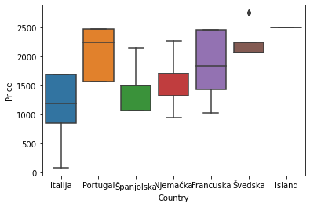

```python
fig = plt.figure()
sns.boxplot(x="Country", y="Price", data=turisti_copy2)
```

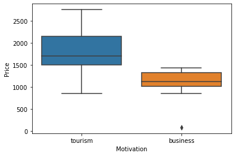

```python
fig = plt.figure()
sns.boxplot(x="Motivation", y="Price", data=turisti_copy2)
```

## Drugi graf prikazuje vezu između motivacije i cijene, cini se da je median ili prosjek cijene za turizam 1700, a najveća bi mogla biti oko 3000, namjanja bi bila 800

## Za poslovno putovanje najmanja je 800, najveća je 1400, dok je prosjek 1200

## Samim time mozemo zakljuciti da se agencija najviše koristi za turisticka putovanja nego za poslovna

```python
turisti_copy2 ["Price"].agg (["count","min","max","mean"])
```

```
count     298.000000
min        85.000000
max      2760.000000
mean     1665.385906
Name: Price, dtype: float64
```

```python
turisti_class=turisti_copy2.groupby(["Country","City","Motivation"])
```

```python
turisti_class ["Price"].max()
```

```
Country     City       Motivation
Francuska   Lyon       business      1435.0
                       tourism       2460.0
            Paris      business      1435.0
                       tourism       2460.0
Island      Reykjavík  tourism       2500.0
Italija     Milano     busines        850.0
                       business      1190.0
                       tourism       1700.0
            Padova     business      1190.0
                       tourism       1700.0
            Rome       business      1190.0
                       tourism       1700.0
            rome       tourism       1700.0
Njemačka    Berlin     business      1330.0
                       tourism       2280.0
            Frankfurt  business      1330.0
                       tourism       2280.0
Portugal    Lisbon     tourism       2475.0
Španjolska  Barcelona  business      1075.0
                       tourism       2150.0
            Madrid     business      1075.0
                       tourism       2150.0
Švedska     Stockholm  tourism       2760.0
Name: Price, dtype: float64
```

## Podaci su grupirani prema državi, gradu i motivaciji dolaska u područje, kao što vidimo uzeo sam cijenu i da mi da najveću cijenu za određeni grad te motivaciju dolaska

## Za Francusku vidimo da je poslovno najveća 1435, te turisticka 2460

## Island ima samo turizam kao motivaciju te iznosi cijena 2500

## Italija za turizam 1700, poslovna 1190

## Njemačka turizam ima 2280, poslovna 1330

## Portugal samo turisticki ljudi putuju tamo i najveca cijena je 2475

## Španjolska turistički posjet karta je 2150, te poslovno je 1075

## Švedska samo turistički ljud dolaze i najveća cijena je 2760

```python
prosjek_cijeneKarte=turisti_copy2["Price"].mean()
```

```python
prosjek_cijeneKarte
```

```
1665.3859060402685
```

```python
turisti["Price average"]=(turisti_copy2["Price"]/prosjek_cijeneKarte)
```

```python
turisti.head(11)
```

|  | Country | City | NoDays | Motivation | Price | NrPeople | NrCh | Service | Transport | Loyalty | Paymenttype | zscore_cijena | Price average |
| --- | --- | --- | --- | --- | --- | --- | --- | --- | --- | --- | --- | --- | --- |
| 0 | Italija | Padova | 10.0 | tourism | 1700.0 | 4.0 | 2.0 | 700.0 | bus | 6.0 | 2.0 | -0.054194 | 1.020784 |
| 1 | Portugal | Lisbon | 11.0 | tourism | 2475.0 | 6.0 | 4.0 | 250.0 | train | 3.0 | 2.0 | 0.025295 | 1.486142 |
| 2 | Italija | Milano | 5.0 | tourism | 850.0 | 5.0 | 4.0 | 250.0 | airplane | 4.0 | 1.0 | -0.141375 | 0.510392 |
| 3 | Španjolska | Barcelona | 7.0 | tourism | 1505.0 | 5.0 | 3.0 | 500.0 | bus | 4.0 | 1.0 | -0.074194 | 0.903694 |
| 4 | Njemačka | Berlin | 12.0 | tourism | 2280.0 | 4.0 | 2.0 | 700.0 | train | 5.0 | 2.0 | 0.005295 | 1.369052 |
| 5 | Francuska | Paris | 9.0 | tourism | 1845.0 | 4.0 | 2.0 | 700.0 | bus | 2.0 | 1.0 | -0.039322 | 1.107851 |
| 6 | Španjolska | Madrid | 10.0 | tourism | 2150.0 | 6.0 | 4.0 | 250.0 | bus | 4.0 | 3.0 | -0.008039 | 1.290992 |
| 7 | Portugal | Lisbon | 9.0 | tourism | 2025.0 | 4.0 | 2.0 | 700.0 | train | 4.0 | 1.0 | -0.020860 | 1.215934 |
| 8 | Njemačka | Frankfurt | 5.0 | tourism | 950.0 | 1.0 | 0.0 | 1000.0 | airplane | 1.0 | 2.0 | -0.131118 | 0.570438 |
| 9 | Italija | Padova | 7.0 | tourism | 1190.0 | 4.0 | 2.0 | 700.0 | bus | 4.0 | 2.0 | -0.106502 | 0.714549 |
| 10 | Portugal | Lisbon | 11.0 | tourism | 2475.0 | 4.0 | 3.0 | 500.0 | train | 4.0 | 1.0 | 0.025295 | 1.486142 |

```python
turisti["Price per day"]=(turisti_copy2["Price"]/turisti["NoDays"])
```

```python
turisti.head(11)
```

|  | Country | City | NoDays | Motivation | Price | NrPeople | NrCh | Service | Transport | Loyalty | Paymenttype | zscore_cijena | Price average | Price per day |
| --- | --- | --- | --- | --- | --- | --- | --- | --- | --- | --- | --- | --- | --- | --- |
| 0 | Italija | Padova | 10.0 | tourism | 1700.0 | 4.0 | 2.0 | 700.0 | bus | 6.0 | 2.0 | -0.054194 | 1.020784 | 170.0 |
| 1 | Portugal | Lisbon | 11.0 | tourism | 2475.0 | 6.0 | 4.0 | 250.0 | train | 3.0 | 2.0 | 0.025295 | 1.486142 | 225.0 |
| 2 | Italija | Milano | 5.0 | tourism | 850.0 | 5.0 | 4.0 | 250.0 | airplane | 4.0 | 1.0 | -0.141375 | 0.510392 | 170.0 |
| 3 | Španjolska | Barcelona | 7.0 | tourism | 1505.0 | 5.0 | 3.0 | 500.0 | bus | 4.0 | 1.0 | -0.074194 | 0.903694 | 215.0 |
| 4 | Njemačka | Berlin | 12.0 | tourism | 2280.0 | 4.0 | 2.0 | 700.0 | train | 5.0 | 2.0 | 0.005295 | 1.369052 | 190.0 |
| 5 | Francuska | Paris | 9.0 | tourism | 1845.0 | 4.0 | 2.0 | 700.0 | bus | 2.0 | 1.0 | -0.039322 | 1.107851 | 205.0 |
| 6 | Španjolska | Madrid | 10.0 | tourism | 2150.0 | 6.0 | 4.0 | 250.0 | bus | 4.0 | 3.0 | -0.008039 | 1.290992 | 215.0 |
| 7 | Portugal | Lisbon | 9.0 | tourism | 2025.0 | 4.0 | 2.0 | 700.0 | train | 4.0 | 1.0 | -0.020860 | 1.215934 | 225.0 |
| 8 | Njemačka | Frankfurt | 5.0 | tourism | 950.0 | 1.0 | 0.0 | 1000.0 | airplane | 1.0 | 2.0 | -0.131118 | 0.570438 | 190.0 |
| 9 | Italija | Padova | 7.0 | tourism | 1190.0 | 4.0 | 2.0 | 700.0 | bus | 4.0 | 2.0 | -0.106502 | 0.714549 | 170.0 |
| 10 | Portugal | Lisbon | 11.0 | tourism | 2475.0 | 4.0 | 3.0 | 500.0 | train | 4.0 | 1.0 | 0.025295 | 1.486142 | 225.0 |

## Za feature/extraction uzeo sam prosjek cijene po karti i cijenu po danu